# Analysis of Killings by US Police

Trevor McGlynn

2020-06-24

# Introduction

This analysis looks at circumstantial observations for all reported cases of death by police officer between 2015 and 2016. It should be worth mentioning that this analysis comes in the wake of nationwide protests following the deaths of George Floyd, Breonna Taylor, and many more as a result of police violence, predominantly against people of color. The data show the disproportional representation of people of color who are killed by police, and frames this around the idea of *unjust force*: the use of deadly force against someone who is completely unarmed. (This warrants more discussion, as will be mentioned shortly.)

Here is a breakdown of the data set used:

| Files | Sizes_kB |
| --- | --- |
| MedianHouseholdIncome2015.csv | 709.0 |
| PercentagePeopleBelowPovertyLevel.csv | 664.4 |
| PercentOver25CompletedHighSchool.csv | 676.3 |
| PoliceKillingsUS.csv | 227.7 |
| ShareRaceByCity.csv | 1094.4 |

Respectively, these represent data from the 2015 census by census area for median income, percentage of the population below the federal poverty level, the percent of the population that are high school graduates over 25 years old, reported instances of police killings between 2015 and 2017 in the US, and the racial makeup of each city (expressed as a percentage).

### Data Frames Used

- `police` <- Observations of individual killings by police officers
- `cities` <- Combined statistical information about cities represented in the `police` DF

### Potential Issues

*Unjust force* <- BOOL, this indicates a victim was completely unarmed when killed by a police officer. However, this does not account for all cases where one could *reasonably conclude force was unjustified*. This is the lowest baseline that could define force in the context of just or unjust.

*Illness, flee* <- These are subjective judgments given by police officers and could be unreliable.

## Dataset for Police Killings

This first data set contains observations for police killings which occurred in the US. Its variables are a name, date, and ID for each case, the city and state where the incident occurred, the victim’s age and race, and some other details about the victim’s encounter with police (such as whether they had a weapon, or whether the police officer was wearing a body cam).

That said, the scope of this analysis will look at the following from this table:

- Factors during police encounter (race, weapons, mental illness)
- City and state
- Body camera usage
- Dates (in 2015 and 2016)
- Victim characteristics (age, gender, and race)

```r
police <- police %>%
  filter(race != '') %>%
  select(-manner_of_death, -threat_level, flee) %>%
  rename(illness = signs_of_mental_illness, cam = body_camera) %>%
  mutate(name = as.character(name),
         unjust_force = armed == 'unarmed',
         poc = race %in% c('B', 'H', 'N'),
         date = dmy(date),
         age_range = cut(age, breaks = BREAKS)) %>%
  filter(year(date) != 2017) %>%
  arrange(date)
```

## Dataset for Demographic Data

The second data set will join demographics data against cities represented with deaths in the `police` data set by city and state. We’ll also tidy the data for upcoming statistical summaries.

```r
# Create a 'cities' data frame from 'df' which will hold all unique city names
# and their count of police killings, arranged by state then city, which seemed
# like the simplest way to match the tables quickly, given the data on hand
cities <- police %>%
  group_by(city, state) %>%
  select(-name) %>%
  summarize(deaths = n()) %>%
  arrange(state, city)
```

## Univariate Plots

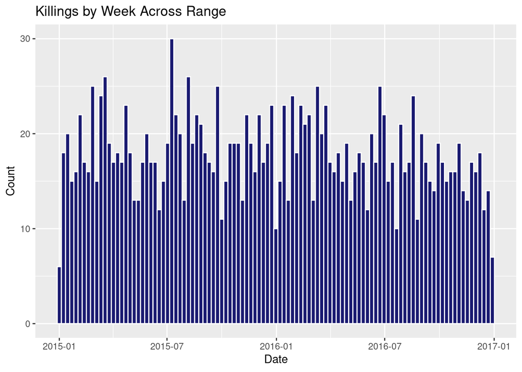

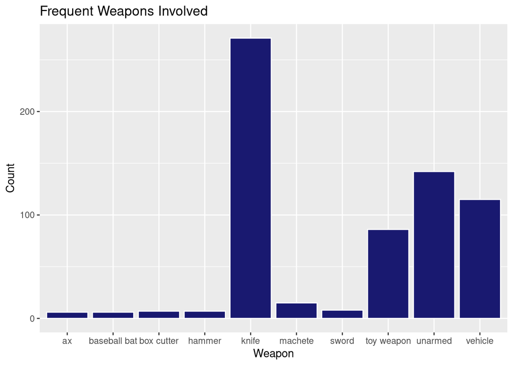

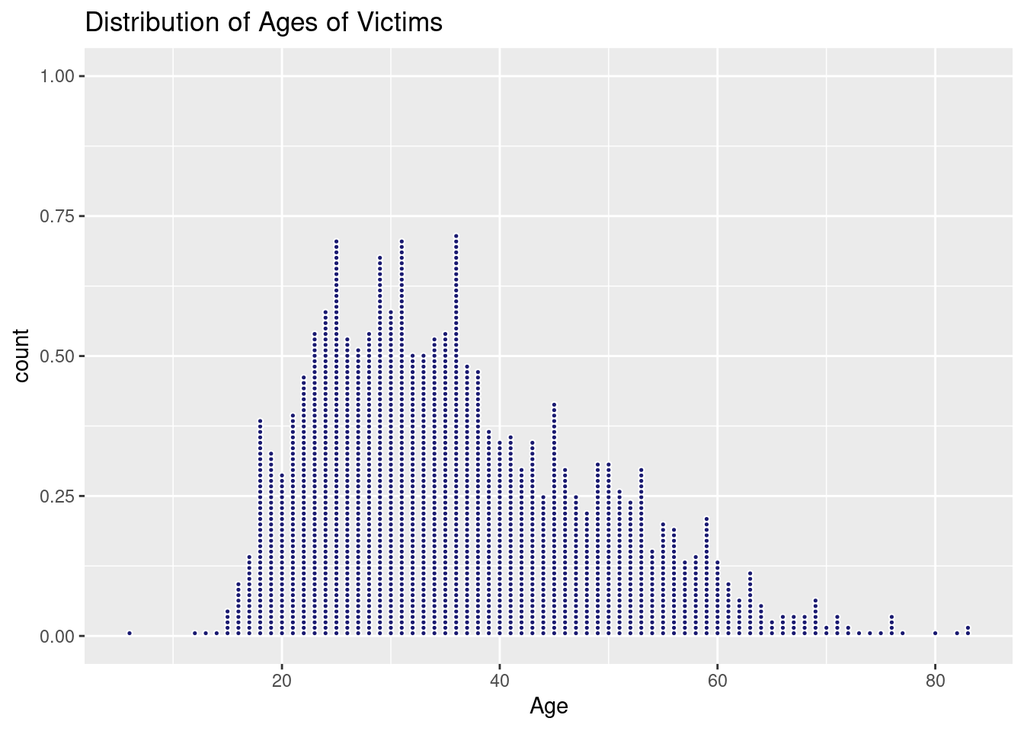

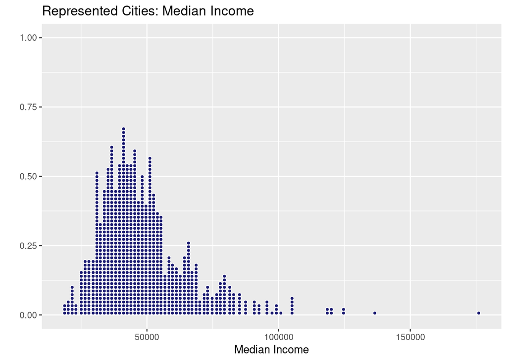

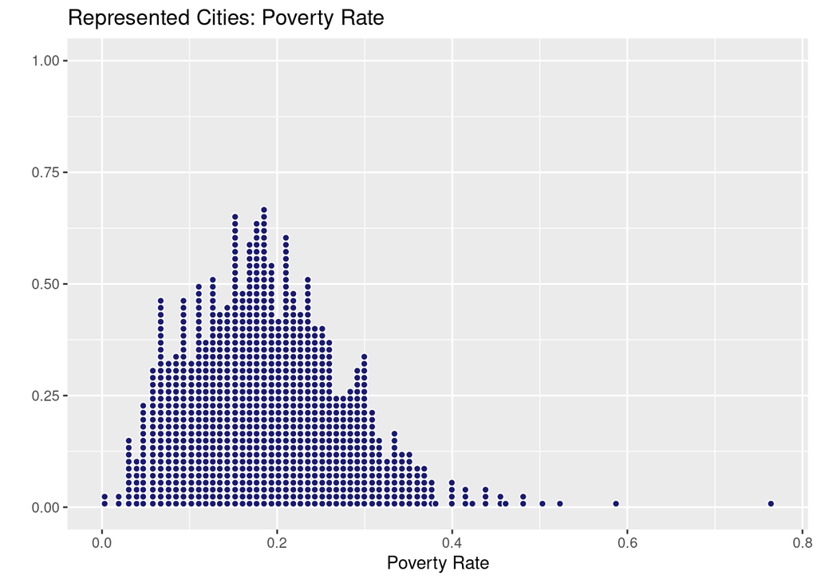

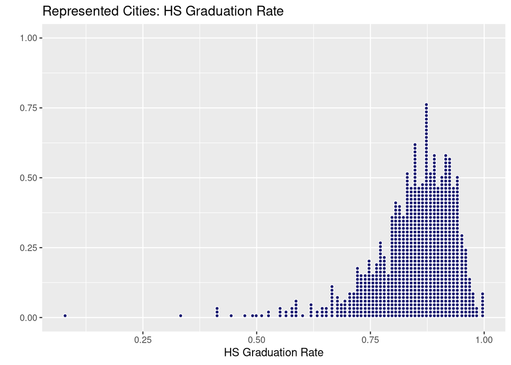

## Univariate Summaries

```
##         armed
##  gun       :1023
##  knife     : 271
##  unarmed   : 142
##  vehicle   : 115
##  toy weapon:  86
##  machete   :  15
##  (Other)   : 114
```

```
##  unjust_force     illness           cam
##  Mode :logical   Mode :logical   Mode :logical
##  FALSE:1721      FALSE:1392      FALSE:1658
##  TRUE :142       TRUE :471       TRUE :205
```

```
##           city          state
##  Los Angeles:  29   CA     : 307
##  Houston    :  22   TX     : 174
##  Phoenix    :  21   FL     : 115
##  Chicago    :  20   AZ     :  87
##  Las Vegas  :  15   CO     :  55
##  Miami      :  15   NC     :  55
##  (Other)    :1741   (Other):1070
```

```
##       age        race       poc
##  Min.   : 6.00    :  0   Mode :logical
##  1st Qu.:26.00   A: 29   FALSE:1015
##  Median :34.00   B:491   TRUE :848
##  Mean   :36.22   H:332
##  3rd Qu.:45.00   N: 25
##  Max.   :83.00   O: 26
##  NA's   :19      W:960
```

```
##      deaths           income          poverty       hs_completion
##  Min.   : 1.000   Min.   : 18085   Min.   :0.0000   Min.   :0.079
##  1st Qu.: 1.000   1st Qu.: 36836   1st Qu.:0.1258   1st Qu.:0.804
##  Median : 1.000   Median : 45283   Median :0.1820   Median :0.861
##  Mean   : 1.585   Mean   : 48709   Mean   :0.1897   Mean   :0.844
##  3rd Qu.: 1.000   3rd Qu.: 55304   3rd Qu.:0.2442   3rd Qu.:0.908
##  Max.   :29.000   Max.   :175990   Max.   :0.7640   Max.   :1.000
##                   NA's   :208      NA's   :203      NA's   :203
```

```
##        W                B                N                 A                 H
##  Min.   :0.0040   Min.   :0.0000   Min.   :0.00000   Min.   :0.00000   Min.   :0.0000
##  1st Qu.:0.5875   1st Qu.:0.0150   1st Qu.:0.00300   1st Qu.:0.00700   1st Qu.:0.0355
##  Median :0.7530   Median :0.0620   Median :0.00500   Median :0.01600   Median :0.0900
##  Mean   :0.7084   Mean   :0.1392   Mean   :0.01523   Mean   :0.03614   Mean   :0.1738
##  3rd Qu.:0.8760   3rd Qu.:0.1865   3rd Qu.:0.01000   3rd Qu.:0.03700   3rd Qu.:0.2275
##  Max.   :1.0000   Max.   :0.9800   Max.   :0.99600   Max.   :0.61900   Max.   :0.9790
##  NA's   :204      NA's   :204      NA's   :204       NA's   :204       NA's   :204
```

## Univariate Analysis

#### Age of Victims

The median age for victims of police shootings is 34, which is higher than expected, and leaving the data set skewed right according to age.

#### Weapons Used

# Bivariate Plots

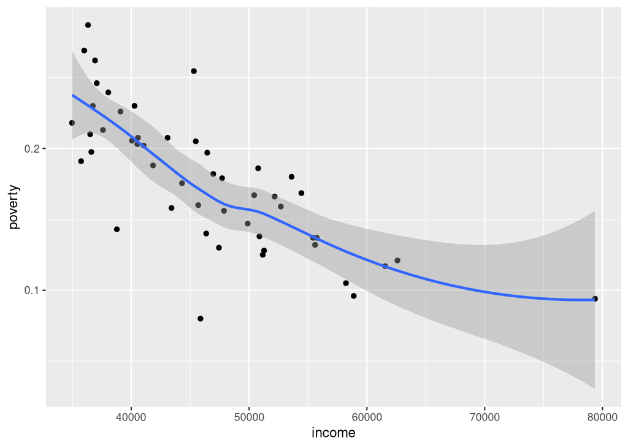

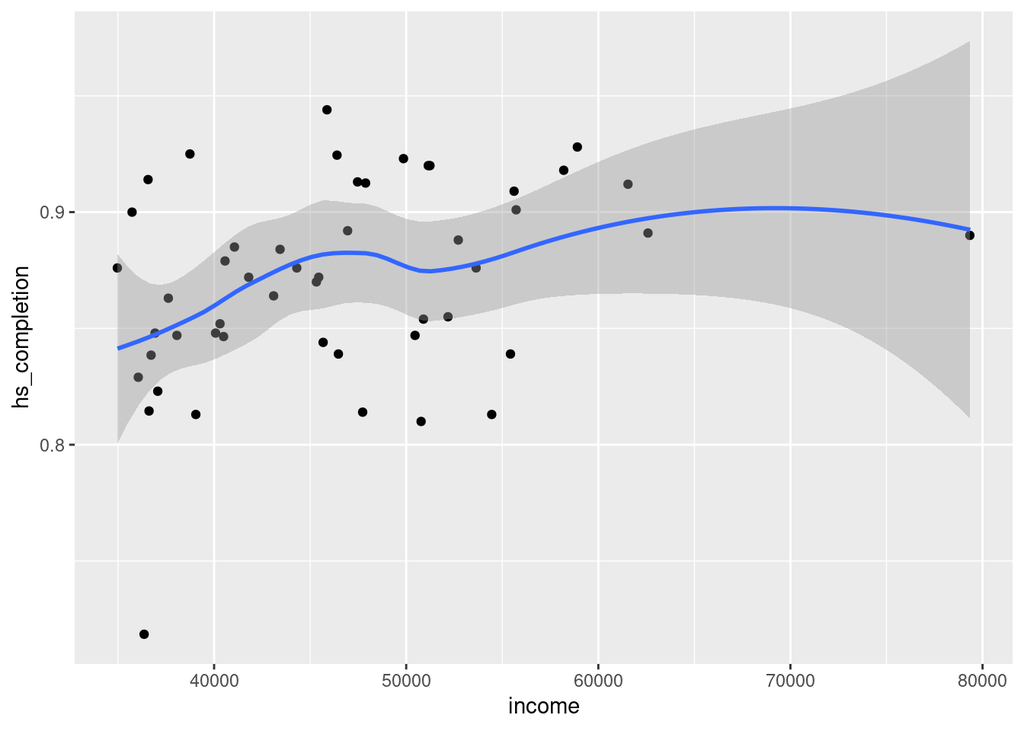

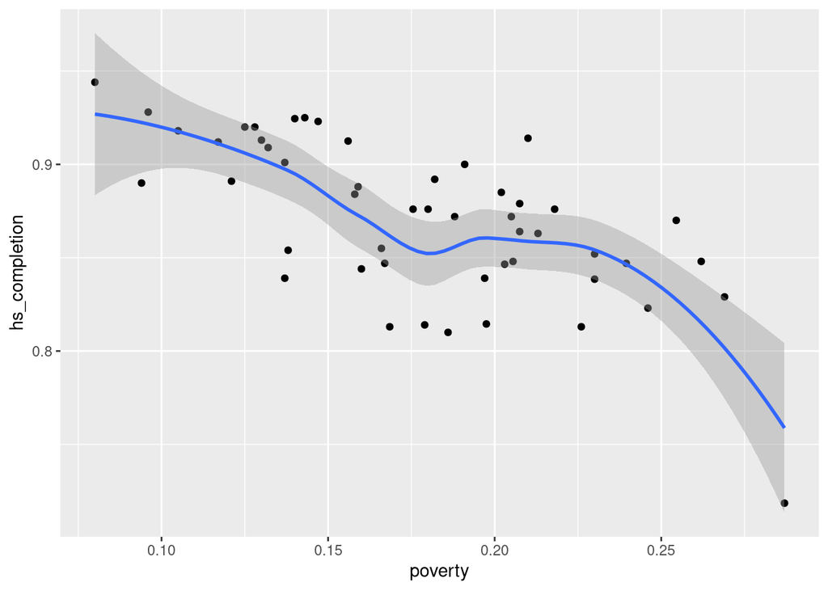

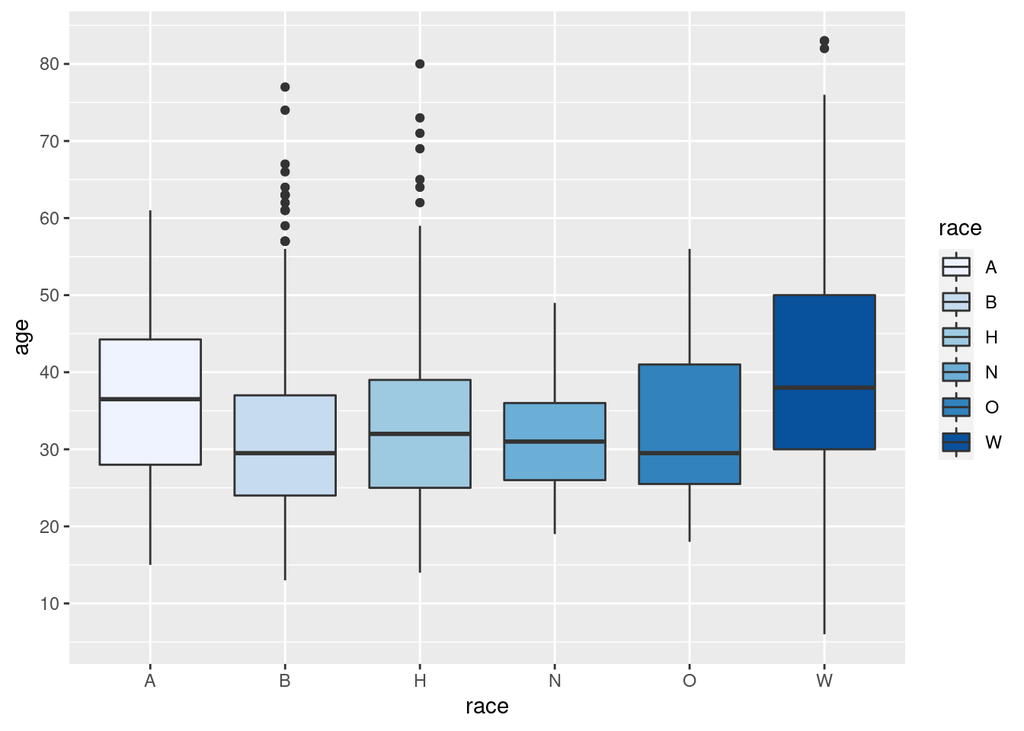

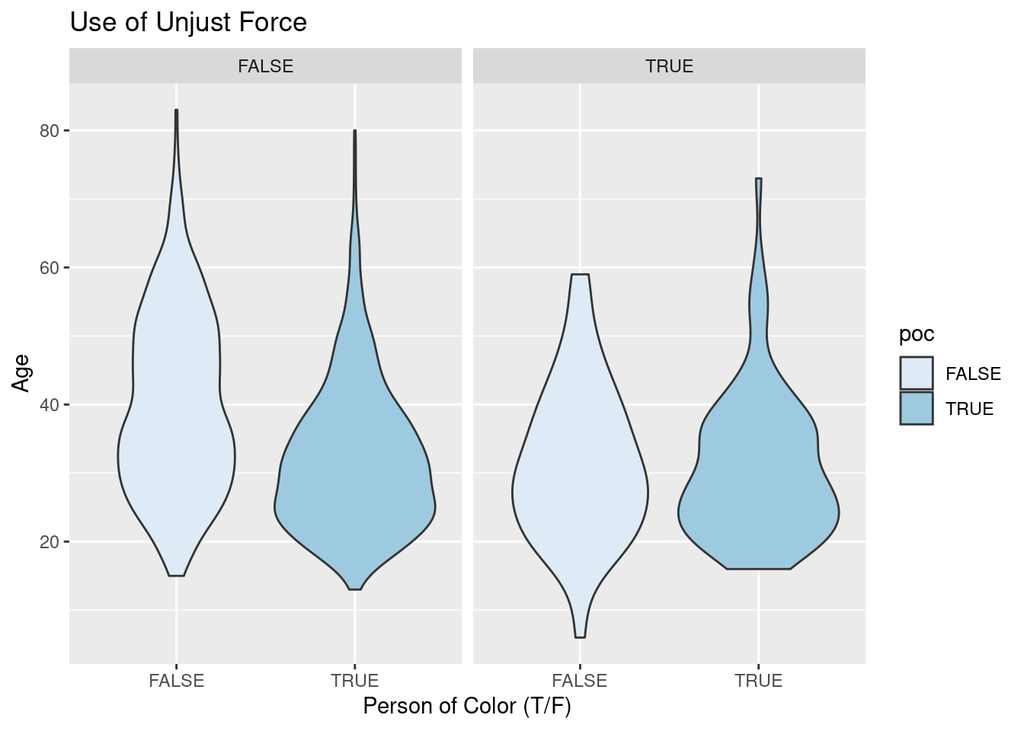

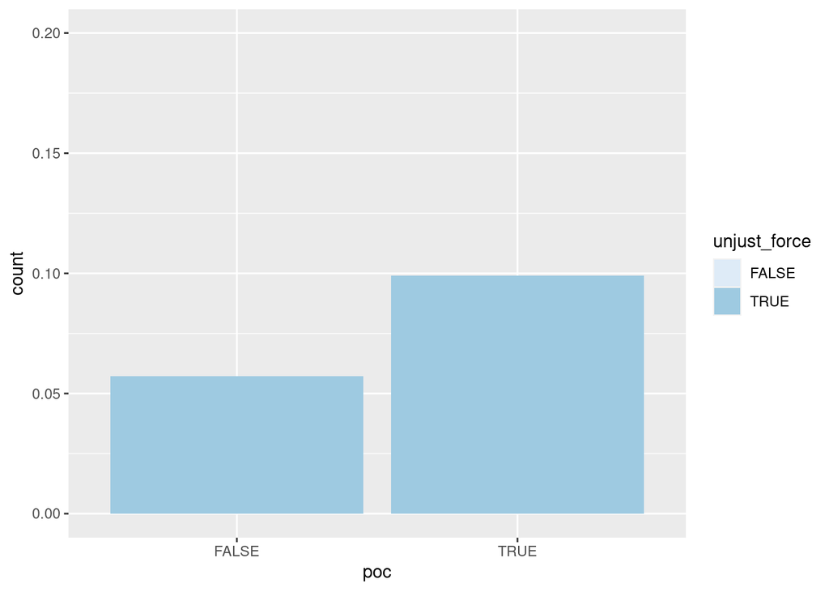

# Bivariate Analysis

#### Demographic Data

Correlations between the components of the demographics data by state yielded less than hoped. The was a negative correlation between poverty level and income, naturally, while high school graduation had a weak positive correlation with income. Likewise, high school graduation and poverty rate had a negative correlation.

### Race and Age

The violin plot on race and age by use of force shows the distribution of age for victims and whether they were a person of color, faceted against the unjust use of force. One key anamoly will be highlighted later in the report.

# Multivariate Plots

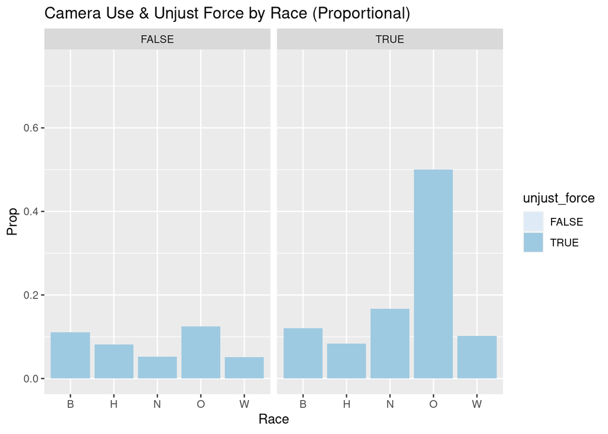

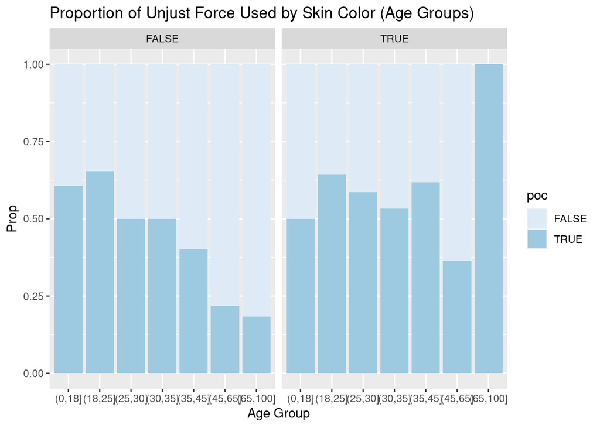

# Multivariate Analysis

### Relationships

# Final Plots and Summary

### Plot One

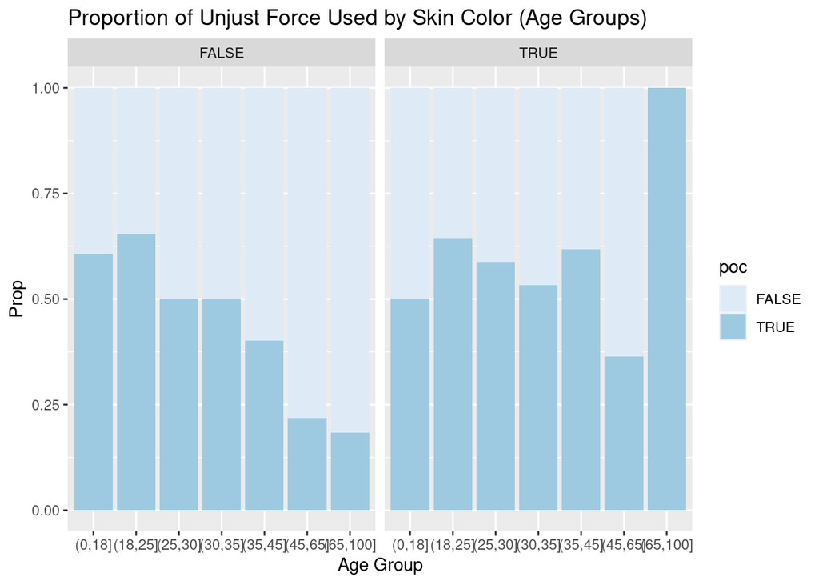

### Description One

This first plot shows quite clearly how, by proportion of police-induced fatalities, people of color make up a dominant proportion of cases against nearly all age groups **where unjust force is used**. Unjust force was defined in the context of this analysis as the *use of deadly force by a police officer on an unarmed victim*. These graphs show the proportion of total fatalities by police, however all of this becomes more striking when considering the racial makeup of the sample itself:

- **Share of PoC Population** in cities represented by this sample: 32.7704124%
- **Share of non-PoC Population** in cities represented by this sample: 74.3350515%

From this analysis, it’s clear that people of color are disproportionately represented in unjustified police violence, and are far more likely to encounter it than white counterparts.

### Plot Two

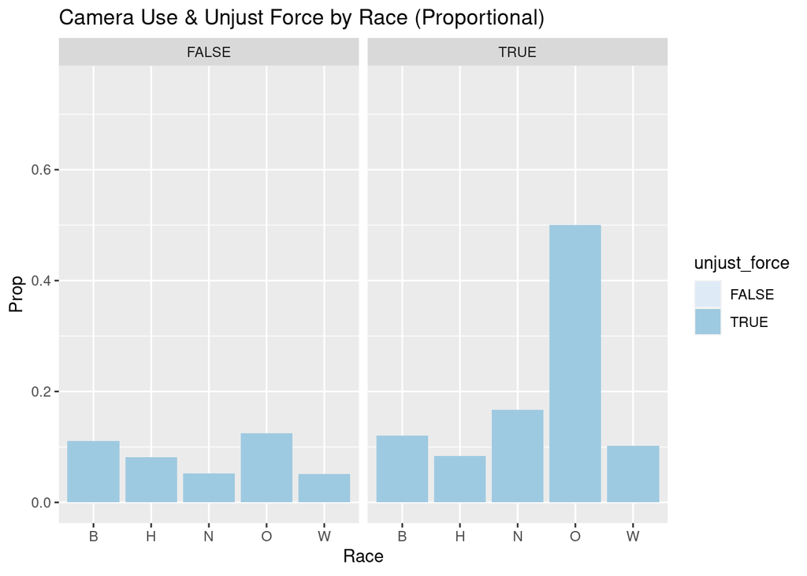

### Plot Three

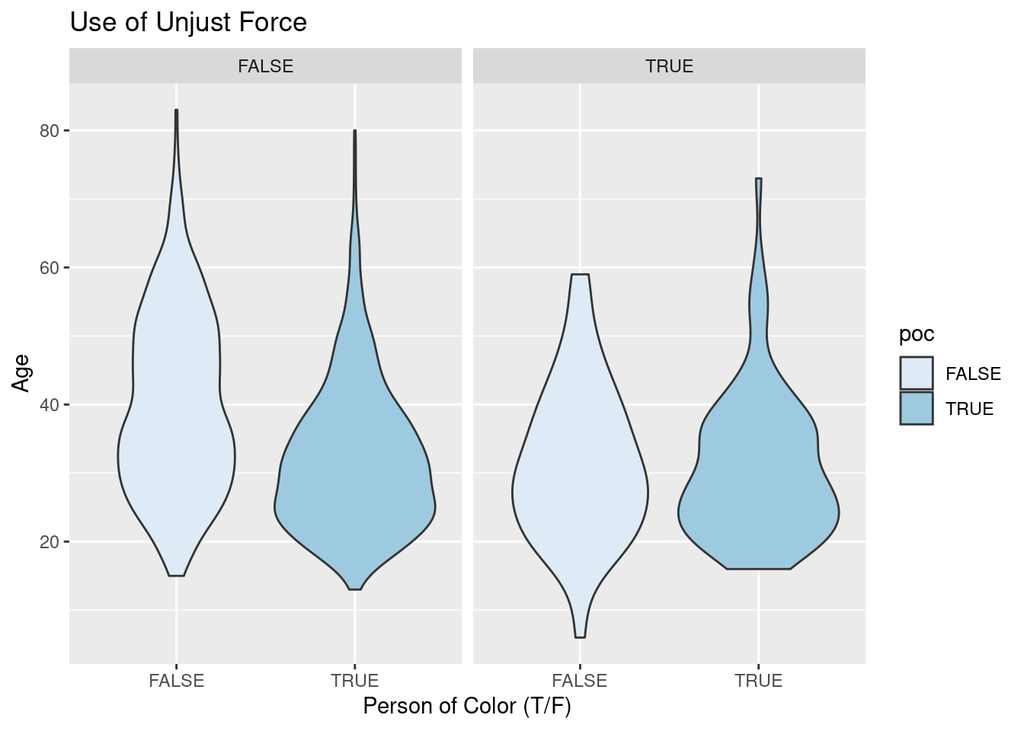

### Description Three

Unjust force by age and race is again clearly shown through this violin plot, but shows an interesting relationship unjust force against persons of color peaks when the victim is in their early twenties, but then increases again in their late thirties. With George Floyd’s death in the spotlight, and many brown men in their late-thirties who have died from unjust use of police force, it’s important to consider this and *why* it may be.

# Reflection

Choosing appropriate plots seems to be the hardest. It helps to breaks the values down and know what’s discrete, what’s continuous, how many variables one plans to include in a plot, and finally what the overall effect should be. This data set dealt with a larger amount of discrete variables; knowing what works well for more variables requiring continuous analysis should be considered for future projects.

Knowing how best to work with bivariate plots, specifically correlations, is another point of improvement needed for future analyses.